# Practice: Bimodal Networks

Alexey Machikhin

5/19/2022

```r
library(igraph)
```

### Bimodal (bipartite) networks

**Part 1. Create a toy bimodal network**

*1. create a matrix* *2. fill the matrix with people and their preferable coffee shops*

```r
m = matrix(data = sample(0:1, 25, replace = TRUE), nrow = 5, ncol = 5)
colnames(m) = c("Joe", "Jill", "Jeff", "Maya", "Rachel")
rownames(m) = c("Costa", "Starbucks", "Cafe2U", "Petes", "Philz")
```

*Convert the matrix to a bipartite network using graph.incidence() command*

```r
bg = graph.incidence(m)
```

*See the vertex attributes*

```r
V(bg)$type
```

```
##  [1] FALSE FALSE FALSE FALSE FALSE  TRUE  TRUE  TRUE  TRUE  TRUE
```

```r
V(bg)$name
```

```
##  [1] "Costa"     "Starbucks" "Cafe2U"    "Petes"     "Philz"     "Joe"
##  [7] "Jill"      "Jeff"      "Maya"      "Rachel"
```

```r
shape = ifelse(V(bg)$type, "circle", "square") # assign shape by node type
col = ifelse(V(bg)$type, "red", "yellow") # assign color by node type
```

*Plot the network*

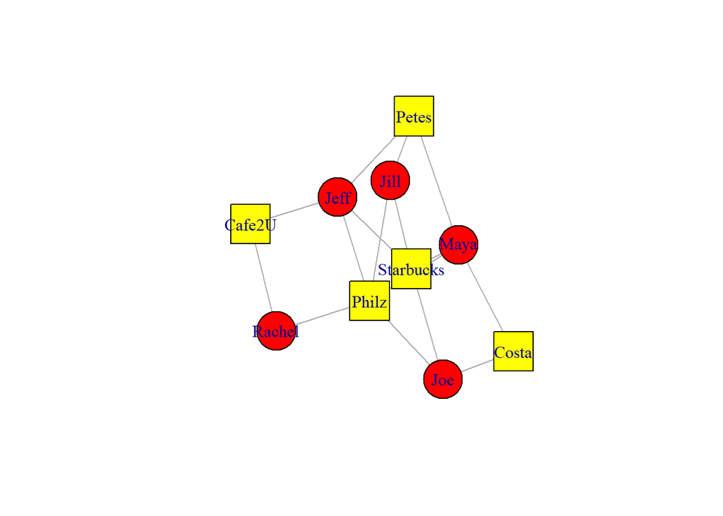

```r
plot(bg, vertex.shape = shape, vertex.color = col, vertex.size = 30)
```

*Projections*

```r
m_row <- m %*% t(m) #creates adjacency matrix of rows
m_column <- t(m) %*% m #creates adjacency matrix of columns
```

*To create a network from the adjacency matrix use command graph_from_adjacency_matrix()*

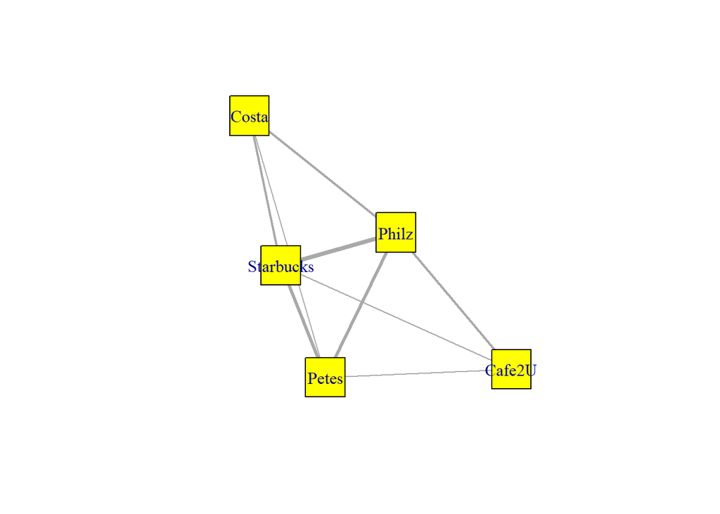

```r
bg_row <- graph_from_adjacency_matrix(m_row,
                          mode = "undirected",
                          diag = FALSE,
                          weighted=TRUE)
e<-E(bg_row)$weight

plot(bg_row, vertex.shape = shape,
     vertex.color = col, vertex.size = 30,
     edge.width = e)
```

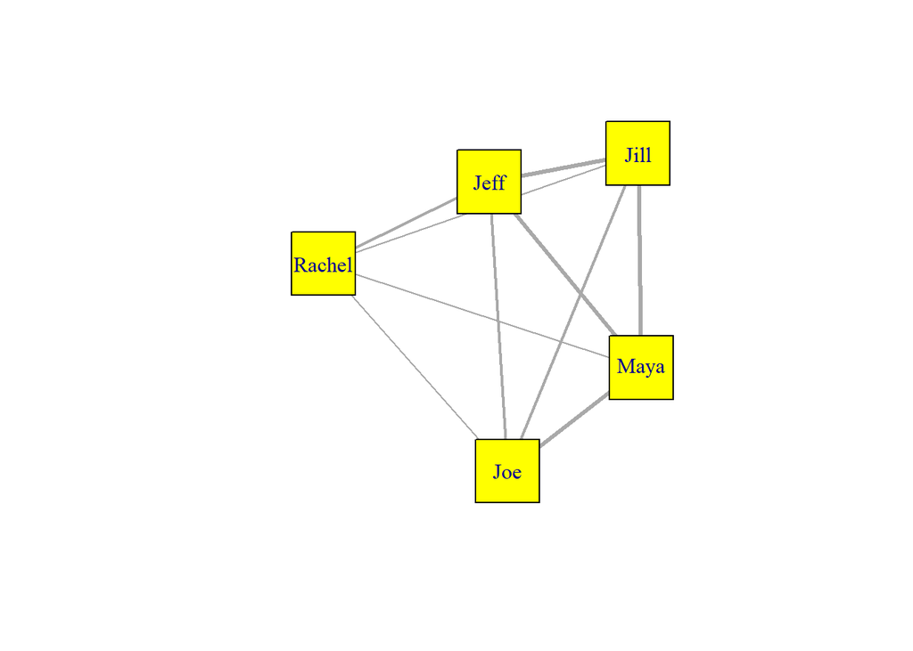

```r
bg_column <- graph_from_adjacency_matrix(m_column,
                            mode = "undirected",
                             diag = FALSE,
                            weighted=TRUE)
e1<-E(bg_column)$weight

plot(bg_column, vertex.shape = shape,
     vertex.color = col, vertex.size = 40,
     edge.width = e1)
```

**Dataset: dataframe containing names and committees, where people are members (“bimodal_Committees & People.csv”)**

*Your task:*

**1. Using the command you just learned, create and draw a bipartite network from a dataframe. When plotting, try two layouts: layout_as_bipartite and layout_with_kk (Kamada-Kawai)**

```r
library(readr)
```

```r
df = read.csv("data/bimodal_Committees & People.csv", header = T, sep = ";")
```

```r
mat = as.matrix(table(df))
```

```r
bg_com = graph.incidence(mat)
```

```r
shape = ifelse(V(bg_com)$type, "square", "circle") # assign shape by node type
col = ifelse(V(bg_com)$type, "tomato3", "lightblue") # assign color by node type
```

```r
knitr::opts_chunk$set(fig.width=10, fig.height=10)
```

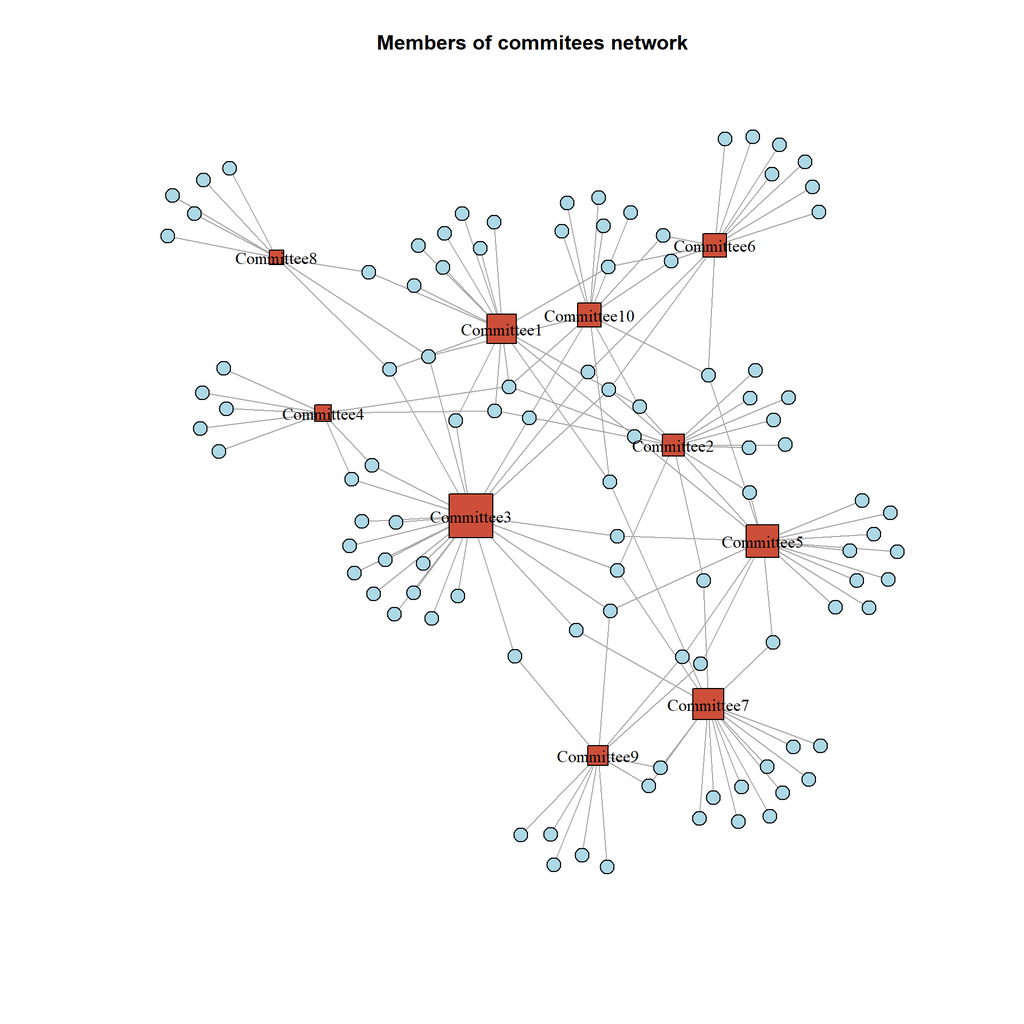

```r
degree_com = degree(bg_com)

plot(bg_com,
     vertex.shape = shape,
     vertex.color = col,
     vertex.size = ifelse(shape == "square", degree_com/2, 4),
     vertex.label = ifelse(shape=="circle", NA, V(bg_com)$name),
     vertex.label.color = "black",
     main = "Members of commitees network")
```

```r
knitr::opts_chunk$set(fig.width=10, fig.height=10)
```

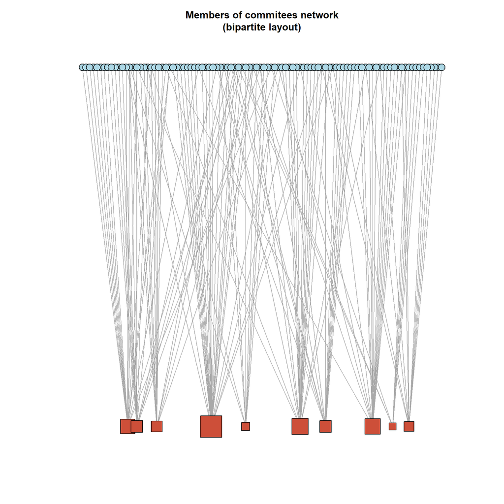

```r
degree_com = degree(bg_com)

plot(bg_com,
     layout = layout_as_bipartite(bg_com),
     vertex.shape = shape,
     vertex.color = col,
     vertex.size = ifelse(shape == "square", degree_com/2, 4),
     vertex.label = NA,
     vertex.label.color = "black",
     main = "Members of commitees network\n(bipartite layout)")
```

```r
knitr::opts_chunk$set(fig.width=10, fig.height=10)
```

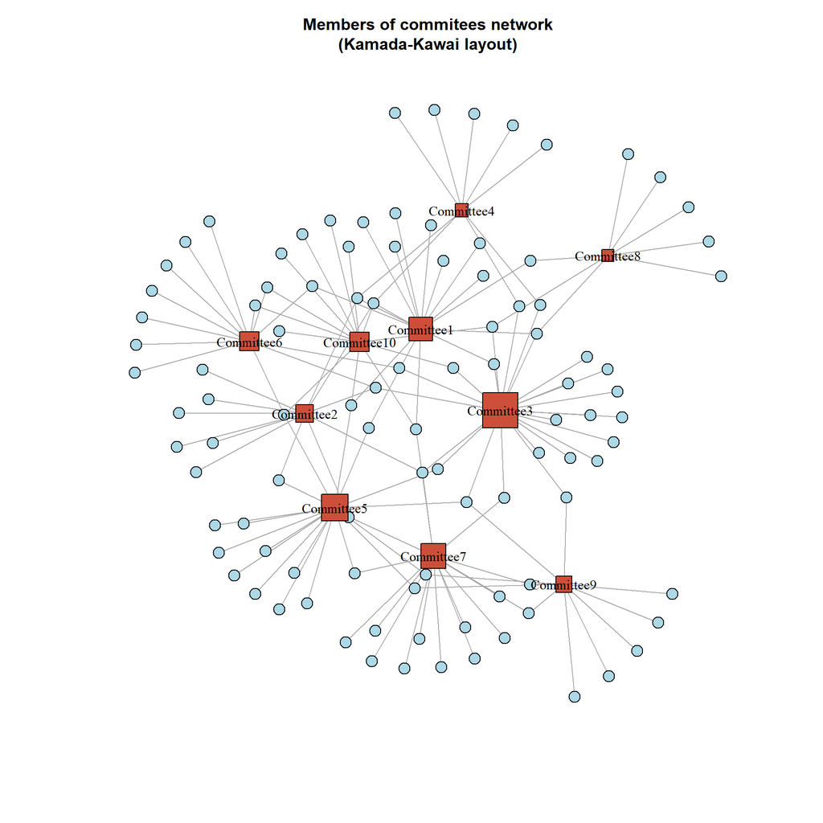

```r
degree_com = degree(bg_com)

plot(bg_com,
     layout = layout_with_kk(bg_com),
     vertex.shape = shape,
     vertex.color = col,
     vertex.size = ifelse(shape == "square", degree_com/2, 4),
     vertex.label = ifelse(shape=="circle", NA, V(bg_com)$name),
     vertex.label.color = "black",
     main = "Members of commitees network\n(Kamada-Kawai layout)")
```

**2. From the bipartite graph, create a network of committee members and a network of committees. Plot both networks**

```r
m_row <- mat %*% t(mat)
m_column <- t(mat) %*% mat
```

```r
knitr::opts_chunk$set(fig.width=10, fig.height=10)
```

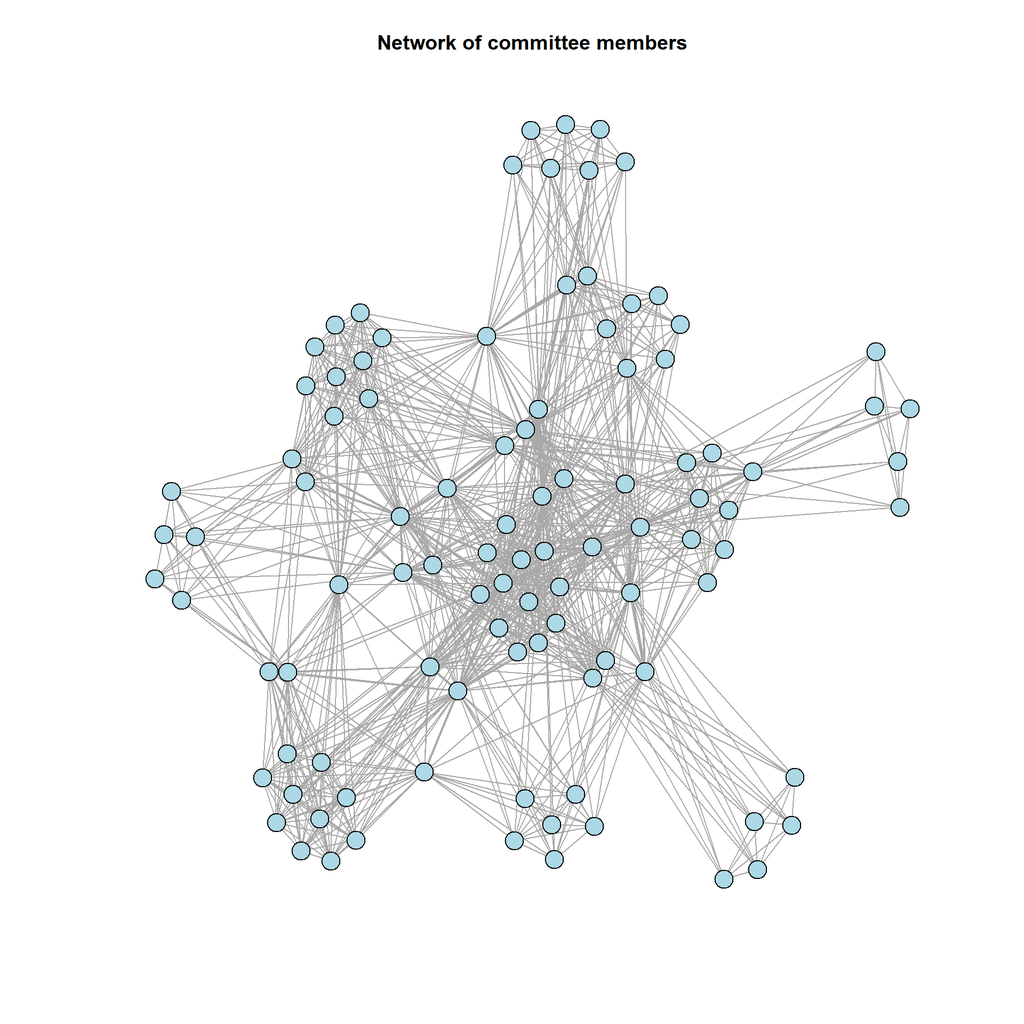

```r
bg_row <- graph_from_adjacency_matrix(m_row,
                          mode = "undirected",
                          diag = FALSE,
                          weighted=TRUE)
e<-E(bg_row)$weight

plot(bg_row, vertex.shape = shape,
     vertex.label = NA,
     layout = layout_with_fr(bg_row),
     vertex.color = col, vertex.size = 5,
     edge.width = e,
     main="Network of committee members")
```

```r
knitr::opts_chunk$set(fig.width=10, fig.height=10)
```

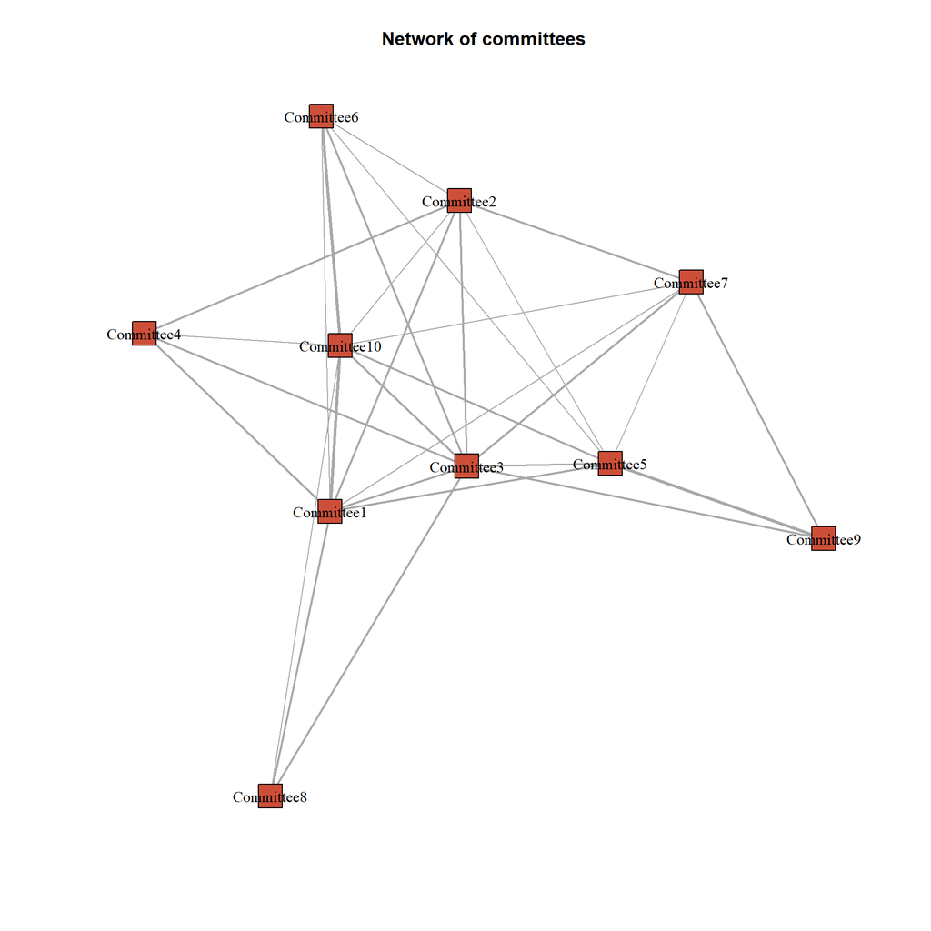

```r
bg_column <- graph_from_adjacency_matrix(m_column,
                            mode = "undirected",
                             diag = FALSE,
                            weighted=TRUE)
e1<-E(bg_column)$weight

plot(bg_column, vertex.shape = "square",
     vertex.label.color = "black",
     vertex.color = "tomato3", vertex.size = 7,
     edge.width = e1,
     main="Network of committees")
```

**Hint:**

To create a bimodal graph from a dataframe, you’ll need to convert df into matrix. An easy way to do it: first convert df into table using command table() Then convert the table into matrix using command as.matrix() Other steps you will find in the example

### Bimodal networks from parsed data

- Here I built bimodal graphs using the data I parsed from VK

#### **Additional Task**

```r
vk = read_csv("data/vk_affilation_matrix.csv")
```

- I’ve parsed network data from VK using Python (request package).
- This data contains information about my VK friends’ public groups subscriptions.
- I’ve parsed a dataset, but I decided to make the affiliation matrix in Python directly so I work with it in R directly.

```r
# Data preprocessing -----
vk_df = vk
vk_df$groups = NULL
rownames(vk_df) = vk$groups
```

```r
M = as.matrix(vk_df) # a matrix to convert to a bipartite network
```

```r
bg = graph.incidence(M) # a bipartite network
```

```r
shape = ifelse(V(bg)$type, "circle", "square") # assign shape by node type
col = ifelse(V(bg)$type, "#aeb0d4", "burlywood") # assign color by node type
```

```r
knitr::opts_chunk$set(fig.width=7, fig.height=5)
```

```r
degree_vk = degree(bg)
summary(degree_vk)
```

```
##    Min. 1st Qu.  Median    Mean 3rd Qu.    Max.
##    1.00    4.00    7.00   12.74   14.00  180.00
```

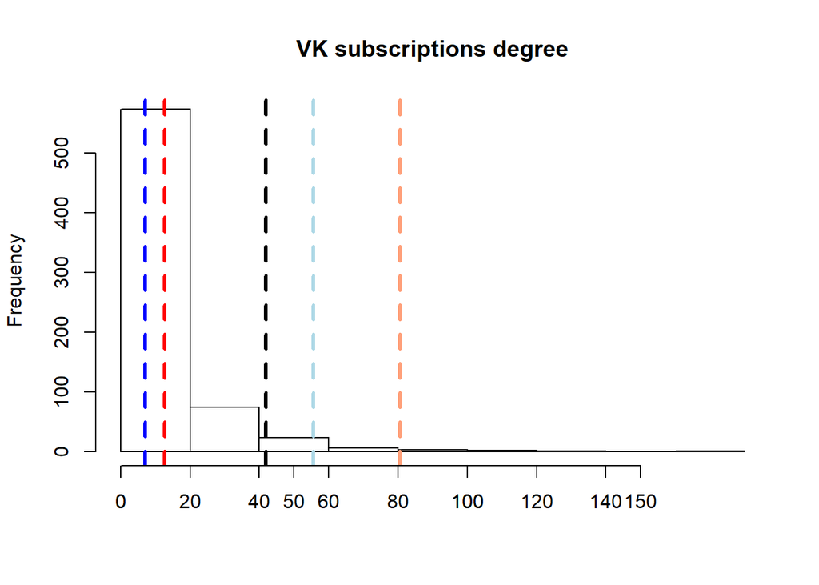

```r
q1 = quantile(degree_vk, 0.95) # 41.8
q2 = quantile(degree_vk, 0.98) # 55.64
q3 = quantile(degree_vk, 0.99) # 80.48
hist(degree_vk, col = 0, main = "VK subscriptions degree", xlab = "")
abline(v = mean(degree_vk), col="red", lwd=3, lty=2)
abline(v = median(degree_vk), col="blue", lwd=3, lty=2)
abline(v = q1, col=1, lwd=3, lty=2)
abline(v = q2, col="lightblue", lwd=3, lty=2)
abline(v = q3, col="lightsalmon", lwd=3, lty=2)
axis(side=1, at=seq(0, 150, by=20))
```

#### Bipartite graph

- *I want to draw communities detected by multi-level optimization of modularity with the cluster_louvain method and keep some disctance between found clusters. Therefore I need to use the written function below to make communities more visible and to put VK public groups names with the most degree centrality:*

```r
edge.weights <- function(community, network, weight.within = 100, weight.between = 1) {
bridges <- crossing(communities = community, graph = network)
weights <- ifelse(test = bridges, yes = weight.between, no = weight.within)
return(weights)
}
```

```r
knitr::opts_chunk$set(fig.width=10, fig.height=10)
```

```r
layout = layout_with_fr(bg)
community = cluster_louvain(bg)
```

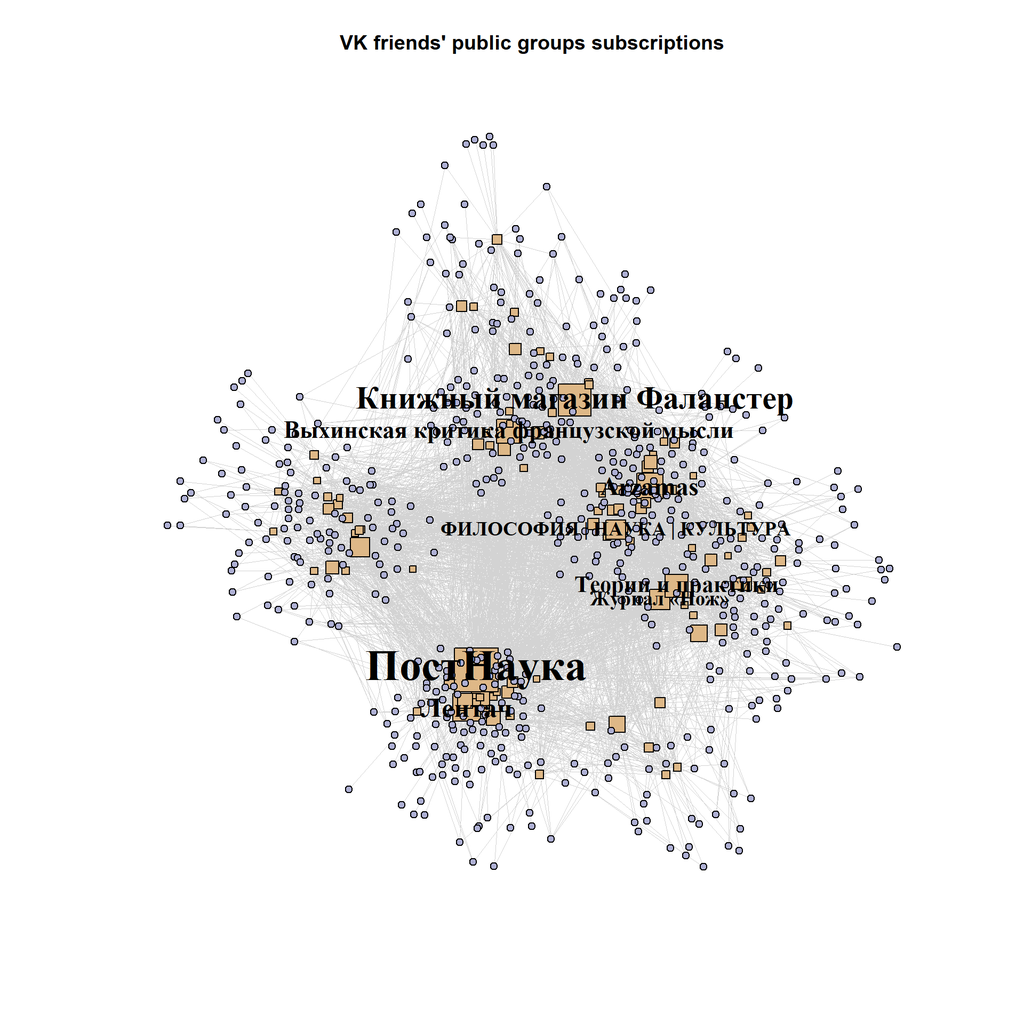

```r
E(bg)$weight = edge.weights(community, bg, weight.within = 50) # weight.within is a positional argument to change distance between communities detected by by multi-level optimization of modularity with the cluster_louvain method

plot(bg,
     vertex.size = ifelse(shape == "square", degree_vk/15, 2),
     vertex.shape = shape,
     vertex.color = col,
     vertex.size = 10,
     vertex.label = ifelse(degree_vk >= 80 & shape == "square", V(bg)$name, NA),
     vertex.label.color = 'black',
     vertex.label.cex = degree_vk/70,
     vertex.label.font = 2,
     edge.width = .1,
     edge.color = "lightgrey",
     main = "VK friends' public groups subscriptions")
```

- Generally, all VK groups are tightly knit. That’s why I put labels only for 8 groups with highest degree centrality. No accident that these most popular among V. Vahshtain VK friends groups are related to science, education or culture.
- ПостНаука is a VK public group with the highest centrality and a separated community of the VK friends is concentrated around this node.
- Нож, Теории и практики and Arzamas are one of the most popular Internet magazines among among students of the humanities and social sciences, teachers and scientists.
- Bookshop Фаланстер - I don’t know what is this place, but this VK group has a great popularity among my VK friends. Analogue of Подписные издания or Все свободны but in Moscow, I guess.
- Лентач is a popular VK news group in a comic format and liberal persuasion.
- Not a great, but some kind of a surprise is that one loveliest VK groups - Выхинская критика французской мысли - also has a high degree centrality. This is a meme group of Moscow HSE philosophy students.

#### Projections

```r
m_row <- M %*% t(M)
m_column <- t(M) %*% M
```

```r
bg_row <- graph_from_adjacency_matrix(m_row,
                          mode = "undirected",
                          diag = FALSE,
                          weighted=TRUE)
```

```r
knitr::opts_chunk$set(fig.width=10, fig.height=10)
```

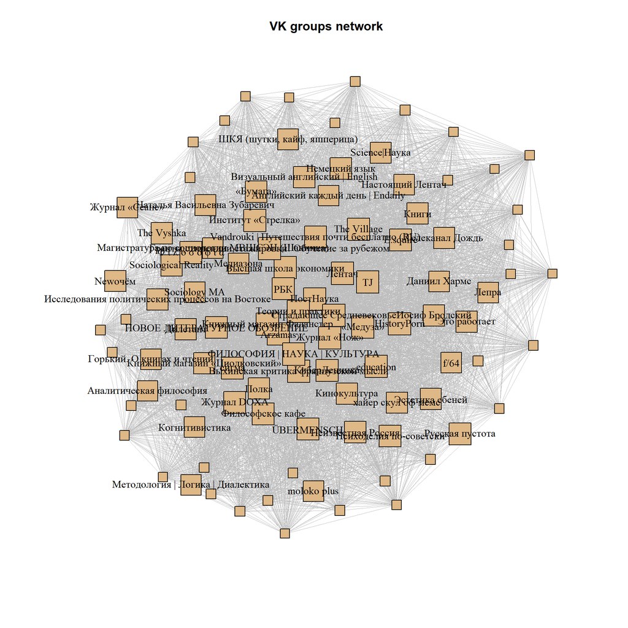

```r
e<-E(bg_row)$weight

degree_vk_row = degree(bg_row)

plot(bg_row,
     vertex.shape = shape,
     layout = layout_nicely(bg_row),
     vertex.color = col,
     vertex.label = ifelse(degree_vk_row >= 90, V(bg_row)$name, NA),
     vertex.label.size = degree_vk_row,
     vertex.size = ifelse(degree_vk_row >= 90, degree_vk_row/10, degree_vk_row/20),
     vertex.label.color = "black",
     edge.width = e/1000,
     edge.color = "grey",
     main = "VK groups network")
```

- As there are 100 most popular VK groups among VK friends, these groups are tightly knit, as it can be seen from the graph above.

```r
bg_column <- graph_from_adjacency_matrix(m_column,
                            mode = "undirected",
                            diag = FALSE,
                            weighted = TRUE)
```

```r
knitr::opts_chunk$set(fig.width=10, fig.height=10)
```

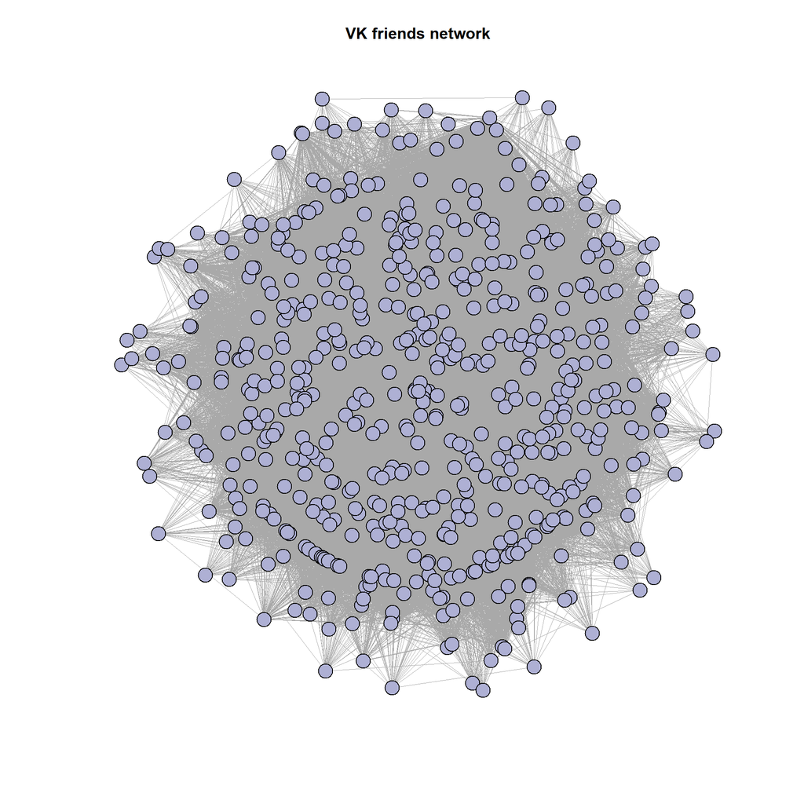

```r
e1<-E(bg_column)$weight

plot(bg_column,
     layout = layout_with_kk(bg_column),
     vertex.shape = "circle",
     vertex.color = "#aeb0d4",
     vertex.size = 5,
     edge.width = e1/2,
     vertex.label = NA,
     main = "VK friends network")
```

- VK friends very often subscribe to the same most popular VK groups.
- As I selected most top-100 popular VK friends’ subscriptions, I conclude that the social environment of this person tends to share common interests (judging by VK subscriptions) mainly related to sociology, science, culture, philosophy and specialized meme communities.